# Gaußprozesse und probabilistisches Programmieren in R

Christoph Schmalhofer  
2019-09-17

### Gaußprozesse sind überall

[figure not shown]

Wahrscheinlichkeitsverteilung von Funktionen

Bayes: Daten -> A-posteriori Gaußprozess

### Anwendungsbeispiele

- Bayes Optimization (Dateneffizienz)
- Zeitreihen
- Nachrichtentechnik
- Geostatistik

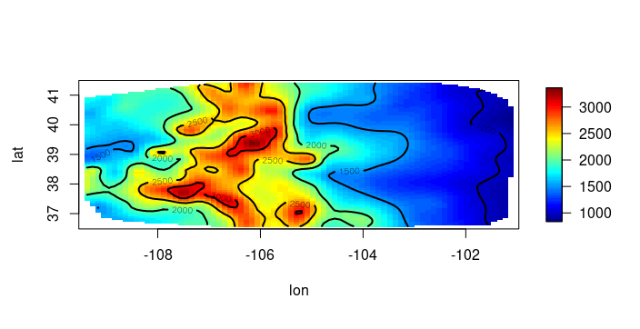

(NCAR fields package)

### Interpolation

- Bayes Posterior versus Konfidenzintervall

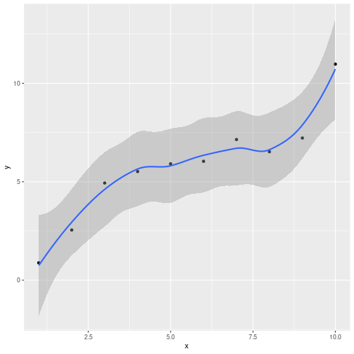

```r
ggplot(data=data.frame(x,y), aes(x=x,y=y)) + geom_point() +  geom_smooth(method="loess", level=0.99, span=0.6)
```

### Interpolation Splines

- Splines

  https://stats.stackexchange.com/questions/144634/splines-vs-gaussian-process-regression

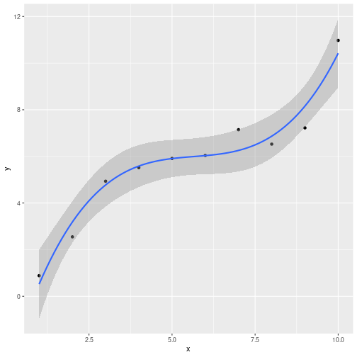

```r
library(splines)
ggplot(data=data.frame(x,y), aes(x=x,y=y)) + geom_point() + geom_smooth(method="lm", formula = "y ~ splines::bs(x,3)")
```

### Einfache Gaußprozesse

- Weißes gaußsches Rauschen
- Lineares Modell
- Random Walk
- Ornstein-Uhlenbeck

### Weißes gaußsches Rauschen

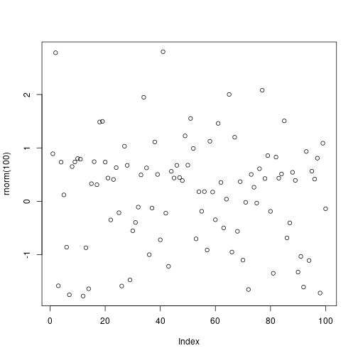

```r
plot(rnorm(100))
```

### Lineares Modell

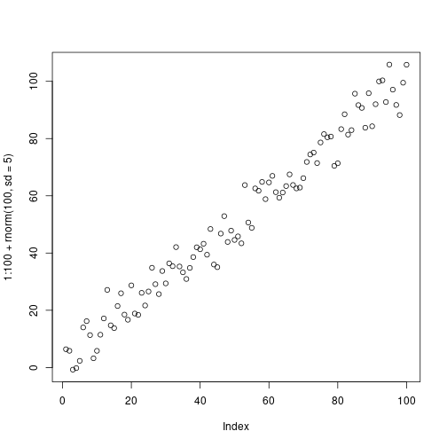

```r
plot(1:100 + rnorm(100, sd=5))
```

### Random Walk I

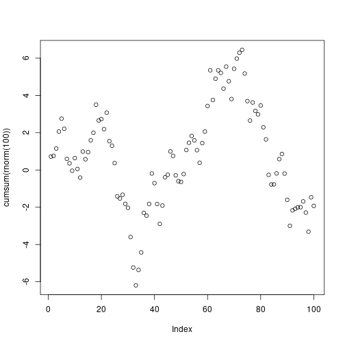

```r
plot(cumsum(rnorm(100)))
```

### Random Walk II

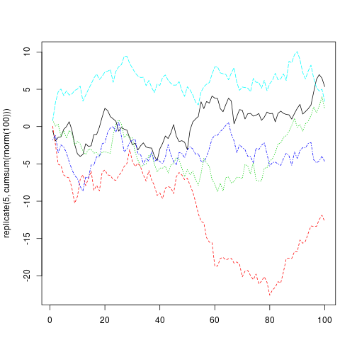

```r
matplot(replicate(5, cumsum(rnorm(100))), type="l")
```

### Ornstein-Uhlenbeck

```r
#https://quant.stackexchange.com/questions/1260/r-code-for-ornstein-uhlenbeck-process
ornstein_uhlenbeck <- function(T, n, x0, nu, lambda, sigma){
dw  <- rnorm(n, 0, sqrt(T/n))
dt  <- T/n
x <- c(x0)
for (i in 2:(n+1)) {
x[i]  <-  x[i-1] + lambda*(nu-x[i-1])*dt + sigma*dw[i-1]
}
return(x);
}
```

x0: Startwert

nu: Attraktor

lambda: Attraktionskraft

### Ornstein-Uhlenbeck (Plot)

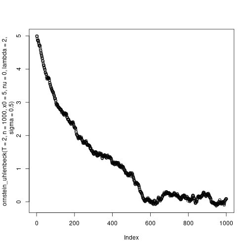

```r
plot(ornstein_uhlenbeck(T=2,n=1000,x0=5,nu=0,lambda=2,sigma=0.5))
```

- https://math.stackexchange.com/questions/2292050/how-is-the-ornstein-uhlenbeck-process-stationary-if-the-mean-and-variance-are-ti

### Gaußprozess Definition

- f ~ GP( mu(x), k(x1, x2) )
- jede Teilmenge ist multivariat normal verteilt
- Erwartungswert: mu(x)
- Kovarianz: k(x1, x2)
- Kovarianz schränkt Art der Funktionen ein

### Multivariate Normalverteilung

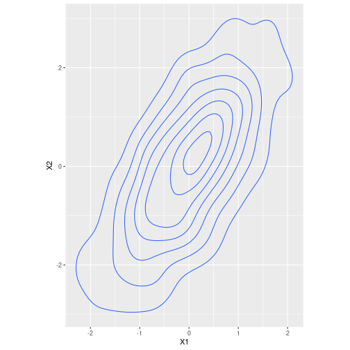

```r
steps <- data.frame(t(replicate(1000, cumsum(rnorm(100)))))
ggplot(data=steps, aes(x=X1, y=X2)) + geom_density_2d() + coord_fixed()
```

(Simulation 1000 Random Walks)

### Multivariate Normalverteilung 99 Schritte

- korrelierte Normalverteilungen

-Schritt 99 ist stark mit Schritt 98 korreliert

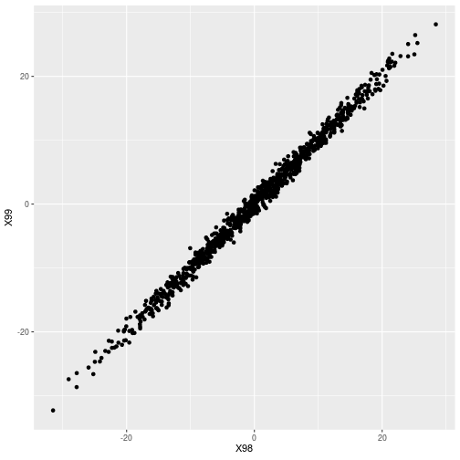

```r
ggplot(data=steps, aes(x=X98, y=X99)) + geom_point() + coord_fixed()
```

### Multivariate Normalverteilung Eigenschaften I

- Die marginalen Verteilungen sind immer normal
- Konditionierung einer Dimension -> restliche Dimensionen bleiben normalverteilt

  A-posteriori bleibt also Gaußprozess

### Multivariate Normalverteilung Eigenschaften II

- Summen bzw. Linearkombinationen bleiben normalverteilt

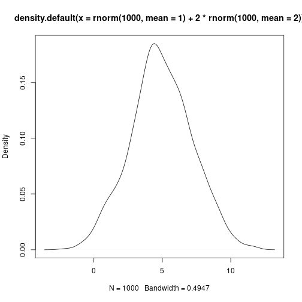

```r
plot(density(rnorm(1000, mean=1) + 2*rnorm(1000, mean=2)))
```

### Multivariate Normalverteilung Persp unkorreliert

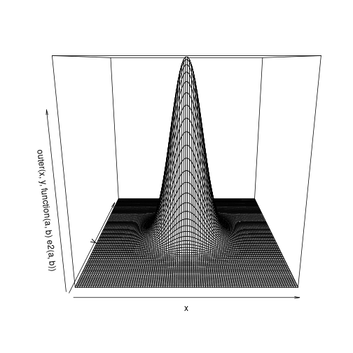

```r
m = diag(2)
e2 <- function(x,y) exp(-rowSums((cbind(x,y) %*% solve(m) * cbind(x,y))))
x <- y<- seq(-4,4, length.out=100)
persp(x=x, y=y, z=outer(x, y, function(a,b) e2(a,b)))
```

### Multivariate Normalverteilung Persp korreliert

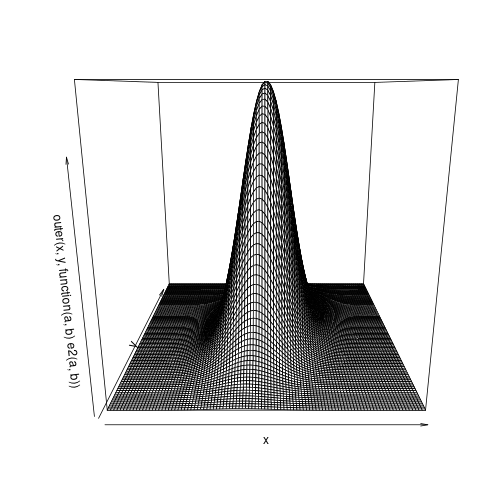

```r
# plotly interaktiv -> Projekt gaussian
m=rbind(c(1.1,0.5), c(0.5,3.1))
persp(x=x, y=y, z=outer(x, y, function(a,b) e2(a,b)))
```

### Kovarianzfunktionen der Beispiele

- weißes Rauschen

  k(x_i, x_j) = kronecker(i, j)
- Random Walk

  k(x1, x2) = min(x1, x2 ) (Einstein 1905)
- Ornstein-Uhlenbeck

### Kovarianzfunktionen

- squared exponential, gaussian, rbf

  k(x1,x2) = sigma<sup>2</sup> * exp(-(x1-x2)<sup>2</sup> / 2*length<sup>2</sup> )

  homogen, isotrop, sehr glatt, length bestimmt Reichweite
- periodisch
- linear
- Duvenaud: Kernel Cookbook

  Murphy: Kapitel 14
- Raum für Kreativität

### Gaußprozess Inferenz

- multivariate Gaußverteilung ist sehr gutartig
- Formeln für Posterior mu und Kovarianz (keine wilden Integrale)
- Kovarianz Formel mit Matrix Inverse -> kubische Komplexität
- Murphy: Kapitel 4

### Inferenz mit GauPro

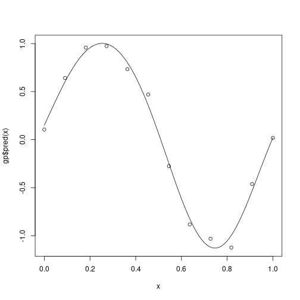

```r
library(GauPro)
n <- 12
x <- matrix(seq(0,1,length.out = n), ncol=1)
y <- sin(2*pi*x) + rnorm(n,0,1e-1)
gp <- GauPro::GauPro(X=x, Z=y)
curve(gp$pred(x));points(x,y)
```

### GauPro Matern Kernel

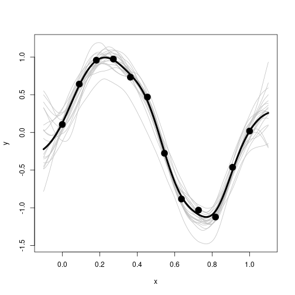

```r
kern <- Matern52$new(0)
gpk <- GauPro_kernel_model$new(matrix(x, ncol=1), y, kernel=kern, parallel=FALSE)
plot(gpk)
```

### Zufallsvariablen -> zufällige Funktion

- Wiener, Kolmogoroff in etwa 1930:

  Wahrscheinlichkeitsverteilung über Funktionen

  (Kolmogorov consistency/extension theorem)
- Heunen, Kammar, Staton, Yang:

  “But standard probability theory cannot support higher-order functions, that is, the category of measurable spaces is not cartesian closed”

### Zufällige Funktionen in R

```r
library(functional)
# linarr: n Werte einer Gerade a + b*x (im Intervall [0,1])
linarr <- function(n,a,b) a + b * seq(0, 1, length.out = n)

# mk_lin_ab erzeugt Closure (a und b gefangen, n bleibt frei)
mk_lin_ab <- function(a,b) Curry(linarr, a=a, b=b)

#Liste von 5 zufälligen linearen Funktionen (Non Standard Evaluation)
random_lins = replicate(5,mk_lin_ab(runif(1), runif(1, min=0.8, max=1.2)))

# Wrapper für dynamischen Funktionsaufruf mit einen Parameter
call_with_n <- function(n) Curry(do.call, args=list(n))

twenty_values_each <- sapply(random_lins, call_with_n(20))
```

### Zufällige Funktionen in R (Plot)

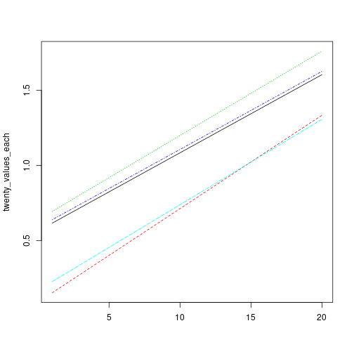

```r
matplot(twenty_values_each, type="l")
```

### Stan Linear Model

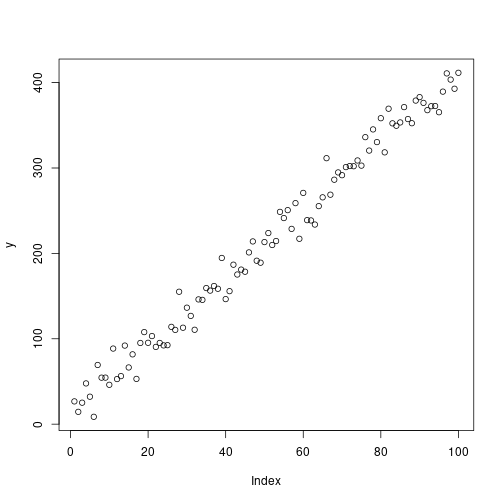

```r
library(rstan)
options(mc.cores = parallel::detectCores())
rstan_options(auto_write = TRUE)

library(rstanarm)
n = 100
x <- 1:n
y <-  12 + 4*x + rnorm(n, sd=13)
plot(y)
```

### Stan Linear Model Fit

```r
fit <- stan_lm( y ~ x, prior = R2(location = 0.5, what="mean"), chains=1)
```

### Stan Linear Model Summary

```r
summary(fit)
```

```
Model Info:

 function:     stan_lm
 family:       gaussian [identity]
 formula:      y ~ x
 algorithm:    sampling
 priors:       see help('prior_summary')
 sample:       1000 (posterior sample size)
 observations: 100
 predictors:   2

Estimates:
                mean   sd     2.5%   25%    50%    75%    97.5%
(Intercept)     13.2    3.3    7.3   11.0   12.9   15.2   19.9
x                4.0    0.1    3.8    3.9    4.0    4.0    4.1
sigma           15.3    1.1   13.4   14.6   15.2   16.0   17.6
log-fit_ratio    0.0    0.0    0.0    0.0    0.0    0.0    0.0
R2               1.0    0.0    1.0    1.0    1.0    1.0    1.0
mean_PPD       213.7    2.2  209.3  212.3  213.8  215.3  218.2
log-posterior -417.9    1.3 -421.3 -418.5 -417.6 -416.9 -416.4

Diagnostics:
              mcse Rhat n_eff
(Intercept)   0.2  1.0  289
x             0.0  1.0  302
sigma         0.1  1.0  372
log-fit_ratio 0.0  1.0  292
R2            0.0  1.0  371
mean_PPD      0.1  1.0  832
log-posterior 0.1  1.0  287

For each parameter, mcse is Monte Carlo standard error, n_eff is a crude measure of effective sample size, and Rhat is the potential scale reduction factor on split chains (at convergence Rhat=1).
```

### Stan Linear Model Plot

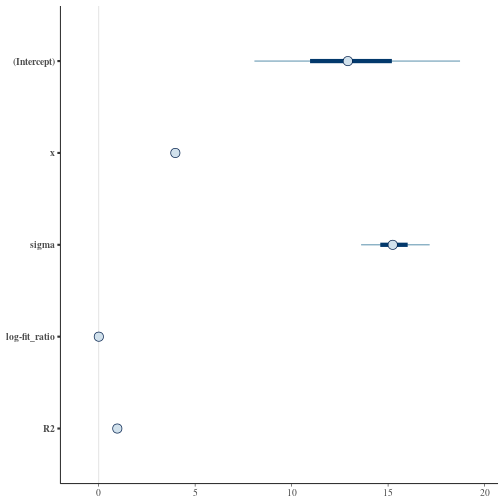

```r
plot(fit)
```

### Stan Gaußprozess Modell (Stan Examples Project)

```
// Fit the hyperparameters of a Gaussian process with an
// exponentiated quadratic kernel

data {
  int<lower=1> N;
  real x[N];
  vector[N] y;
}
transformed data {
  vector[N] mu = rep_vector(0, N);
}
parameters {
  real<lower=0> rho;
  real<lower=0> alpha;
  real<lower=0> sigma;
}
model {
  matrix[N, N] L_K;
  matrix[N, N] K = cov_exp_quad(x, alpha, rho);
  real sq_sigma = square(sigma);

  // diagonal elements
  for (n in 1:N)
    K[n, n] = K[n, n] + sq_sigma;

  L_K = cholesky_decompose(K);

  rho ~ inv_gamma(5, 5);
  alpha ~ normal(0, 1);
  sigma ~ normal(0, 1);

  y ~ multi_normal_cholesky(mu, L_K);
}
```

### Stan Gaußprozess Fit

```r
stan_dat <- read_rdump('gp-fit.data.R')

fit_gp <- stan(file="gp-fit.stan", data=stan_dat,
               iter=200, chains=1)
```

### Stan Gaußprozess Print

```r
print(fit_gp, pars = c('rho','alpha','sigma'))
```

```
Inference for Stan model: gp-fit.
1 chains, each with iter=200; warmup=100; thin=1;
post-warmup draws per chain=100, total post-warmup draws=100.

      mean se_mean   sd 2.5%  25%  50%  75% 97.5% n_eff Rhat
rho   1.18    0.05 0.35 0.70 0.97 1.13 1.28  2.20    50 1.00
alpha 0.50    0.03 0.20 0.25 0.34 0.43 0.66  0.86    37 0.99
sigma 0.34    0.00 0.03 0.29 0.32 0.34 0.36  0.40   121 0.99

Samples were drawn using NUTS(diag_e) at Sun Sep 15 18:00:51 2019.
For each parameter, n_eff is a crude measure of effective sample size,
and Rhat is the potential scale reduction factor on split chains (at
convergence, Rhat=1).
```

### Stan Gaußprozess Plot

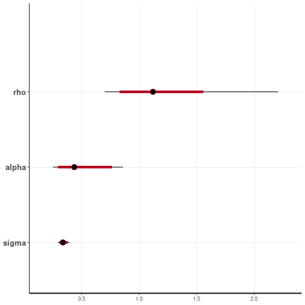

```r
plot(fit_gp)
```

### Probabilistic Language Stuff: Stan, pqR

- Stanc3 Type System (Monaden für Stan?)
- https://discourse.mc-stan.org/t/stanc3-type-system-overhaul/10988

  Sean Talts. “@enetsee has brought up the idea of refactoring this such that distributions are a first class concept in a new type system …”
- The fundamental abstractions underlying BUGS and Stan as probabilistic programming languages

  https://statmodeling.stat.columbia.edu/2017/09/07/fundamental-abstractions-underlying-bugs-stan-probabilistic-programming-languages/
- Radford Neal: An R Language Extension for Automatic Differentiation

  https://radfordneal.wordpress.com/2019/07/06/automatic-differentiation-in-pqr/

### Referenzen

- David MacKay: Introduction to Gaussian Processes

  [https://www.ics.uci.edu/~welling/teaching/KernelsICS273B/gpB.pdf](https://www.ics.uci.edu/%7Ewelling/teaching/KernelsICS273B/gpB.pdf)
- Görtler, Jochen and Kehlbeck, Rebecca and Deussen, Oliver

  https://distill.pub/2019/visual-exploration-gaussian-processes/

### Referenzen Gaußprozesse I

- Andreas Damianou: Gaussian process lecture

  https://nbviewer.jupyter.org/github/adamian/adamian.github.io/blob/master/talks/Brown2016.ipynb
- Richard Turner: “Introduction to Gaussian Processes”

  https://www.youtube.com/watch?v=Jv25sg-IYHU
- scikit-learn: GP zur Klassifizierung - Vergleich mit anderen Methoden

  https://scikit-learn.org/stable/auto_examples/classification/plot_classifier_comparison.html
- scikit-learn: Kernel Beispiele

  https://scikit-learn.org/stable/auto_examples/gaussian_process/plot_gpr_prior_posterior.html#sphx-glr-auto-examples-gaussian-process-plot-gpr-prior-posterior-py

### Referenzen Gaußprozesse II

- http://www.gaussianprocess.org/

  Rasmussen, Williams: “Gaussian Processes for Machine Learning”
- Kevin Murphy “Machine Learning: a Probabilistic Perspective”

  Kapitel 4, 14 und 15
- David MacKay “Information Theory, Inference, and Learning Algorithms”

  Teil V: Neuronalen Netze -> Gaußprozess

### Referenzen Gaußprozesse III

- Michael Betancourt: wie robust sind Gaußprozess Regressionen

  https://betanalpha.github.io/assets/case_studies/gp_part1/part1.html
- Stan User's Guide
- Gaußprozesse in der Geostatistik

  https://github.com/NCAR/fields/blob/master/fieldsVignette.pdf
- David Duvenaud:“The Kernel Cookbook”

  [https://www.cs.toronto.edu/~duvenaud/cookbook/](https://www.cs.toronto.edu/%7Eduvenaud/cookbook/)
- GPyTorch: https://gpytorch.readthedocs.io/en/latest/
- PyMC3

  https://docs.pymc.io/Gaussian_Processes.html